# Aula 2 - Condições, Loops e Funções

Augusto Marcolin

04 de Outubro, 2018

## Condições

### **Comparações (Revisão)**

Na última aula, vimos que podemos comparar tanto números como vetores, utilizando as principais condições:

- `>` e `>=` maior/maior igual
- `<` e `<=` menor/menor igual
- `==` igual
- `!=` diferente
- `%in%` contido

```r
# comparação número vs. número
1 > 2
```

```
## [1] FALSE
```

```r
# comparação vetor vs. número
a <- c(1, -2, 3, -4)

a < 0
```

```
## [1] FALSE  TRUE FALSE  TRUE
```

```r
# comparação vetor vs. vetor

b <- c(0, 5, 10, 15)

c <- c(0, 7, 12, 15)

b %in% c
```

```
## [1]  TRUE FALSE FALSE  TRUE
```

- **Operadores Lógicos**

Quando utilizamos comparadores, muitas vezes necessitamos combinar comparações, para isso existem os operadores lógicos:

- `&` `&&` AND(E)
- `|` `||` OR(OU)
- `!` NOT(NÃO)

Note que a resposta de uma comparação sempre retorna um valor **logical** `TRUE` ou `FALSE`, referente ao resultado. Os operadores lógicos servem para combinar comparações, como exposta no exemplo abaixo:

```r
notas <- c(10, 9, 6.5, 8, 3.5, 2, 6, 9)

# notas maiores que 6 e menores que 9
notas > 6 & notas < 9
```

```
## [1] FALSE FALSE  TRUE  TRUE FALSE FALSE FALSE FALSE
```

```r
# notas menores que 4 ou maiores que 9
notas < 4 | notas > 9
```

```
## [1]  TRUE FALSE FALSE FALSE  TRUE  TRUE FALSE FALSE
```

```r
# notas que não são menores que 6
!(notas < 6)
```

```
## [1]  TRUE  TRUE  TRUE  TRUE FALSE FALSE  TRUE  TRUE
```

O operador `!` reverteu o resultado do vetor lógico. Esse artificio pode ser bem útil quando queremos elementos que não estão no vetor. Por exemplo, temos dois vetor, um contendo o alfabeto e outro contendo as vogais. Queremos um vetor que contenha apenas as consoantes:

```r
vogais <- c("a", "e", "i", "o", "u")

alfabeto <- letters

filtro <- !(alfabeto %in% vogais)

consoantes <- alfabeto[filtro]
```

- **Outros Comparadores**

Há situações em que os comparadores apresentados não são o suficientes, isto é, quando temos dados faltantes `NA` ou quando queremos saber a classe de uma variável.

```r
#--- NA
vetor_NA <- c(1, NA, 2, 4, NA)

is.na(vetor_NA)
```

```
## [1] FALSE  TRUE FALSE FALSE  TRUE
```

```r
#--- classe
is.character(vetor_NA)
```

```
## [1] FALSE
```

A utilização da função `is.na` é muito importante quando queremos remover casos faltantes.

> Let’s do

Primeiramente escreva a base de dados de notas de alunos que está no código abaixo. Sua nota será representada pelo valor `minha_nota`

```r
notas <- round(runif(100, 0, 10), digits = 1)
minha_nota <- 7
```

- Veja se sua nota é maior que a média da turma
- Dado que a média para passar é 6, monte um vetor com os alunos que não atingiram a nota, de duas maneiras: utilizando o operador `>` ou `<` e utilizando o operador `!`.

### **`if`**

Tomar decisões é uma parte importante da programação. Indiferente de outras linguagens de programação, o R também tem sua condição “**se**”, representada pelo comando `if`, cuja sintaxe é mostrada abaixo:

```r
if(condicao){
  código
}
```

O `if` funciona como um tomador de decisão sobre uma condição, ou seja, se uma condição for satisfeita, o `if` permite que a execução do código seja feita.

Vejamos um exemplo, suponha que queremos mostrar na tela uma mensagem “Número Positivo”, caso uma variável seja maior que 0.

```r
x <- 5

if(x > 0){
  print("Número Positivo")
}
```

```
## [1] "Número Positivo"
```

### **`if` `else`**

Podem haver situações que queremos executar um código se uma condição é verdadeira, e caso não for, executar um código diferente. É nesse momento que executamos o `else`, que pode ser interpretado no sentido literal como: “caso contrário”.

A sintaxe pode ser vista a seguir:

```r
if(condicao){
  código
} else{
  código
}
```

Seguindo no exemplo anterior, caso o número não seja maior que 0, queremos mostrar uma mensagem “Número menor ou igual 0”.

```r
x <- -5

if(x > 0){
  print("Número Positivo")
} else{
  print("Número menor ou igual a 0")
}
```

```
## [1] "Número menor ou igual a 0"
```

### **`ifelse`**

Além disso, o R possui uma função chamada `ifelse`, onde você pode fazer seus testes e atribuir valores à uma variável caso o teste seja satisfeito ou não.

```r
ifelse(test = condicao, yes = código, no = código)
```

Suponha que você tenha um data.frame chamado **scores** contém duas colunas, **id** - id do cliente e **score** - o score de fraude do cliente. Digamos que você tenha que criar uma nova variável contendo a descrição de que se o cliente é fraude ou não, baseado no score. Quem tem score maior que 0.75, você diz que é fraude, caso contrário, não fraude:

```r
set.seed(1983) # cria uma semente aleatória

scores <- data.frame(
  id  = 1:10,
  score = runif(10) #sorteia 10 números entre 0 e 1
  )

head(scores)
```

```
##   id     score
## 1  1 0.4931975
## 2  2 0.1526182
## 3  3 0.2166163
## 4  4 0.7472593
## 5  5 0.9076840
## 6  6 0.2210163
```

```r
scores$label <- ifelse(scores$score > 0.75, "fraude", "n_fraude")

head(scores)
```

```
##   id     score    label
## 1  1 0.4931975 n_fraude
## 2  2 0.1526182 n_fraude
## 3  3 0.2166163 n_fraude
## 4  4 0.7472593 n_fraude
## 5  5 0.9076840   fraude
## 6  6 0.2210163 n_fraude
```

> Let’s do

Voltando ao exemplo das notas.

1. Imprima na tela a mensagem “Você foi aprovado” se sua nota é maior que 6, caso contrário, imprima “Você foi reprovado”
2. crie um vetor que tenha a descrição “passou” e “n_passou” para cada uma das notas, depois junte em um data.frame.

## Loops

Loops são replicações de uma mesma parte de código, podendo ser dividos em dois tipos: replicações de um código em um número previamente limitado(`for`) ou baseados em condições lógicas(`while`)

### **`for`**

Como dito anteriormente, o `for` é uma replicação de código em que o número de repetições é previamente definido. No R, definimos o número de repetições um vetor com uma sequência numérica. Podemos fazer de dois jeitos:

1. Escolhendo a sequência “na mão”.
2. Formando a sequência baseada no tamanho de um vetor

```r
# sequência de 1 a 10

for(i in 1:10){
  print(i)
}

# sequência baseada no tamanho de um vetor
a <- c(5, 10, 20, 30, 45)

for(i in 1:length(a)){
  print(a[i])
}
```

- **Encadeamento de For**

Quando estamos trabalhando com matrizes ou data frames, temos linhas e colunas. Um dos métodos para percorrer pelas linhas e colunas é utilizando um encadeamento de for.

```r
# sequência de 1 a 10

for(i in 1:5){

  for(j in 1:2){
    print(paste0("valor de i:", i))
    print(paste0("valor de j:", j))
  }

}
```

### **`while`**

O while é um loop que irá replicar comandos até que uma condição seja aceita, ele é útil quando queremos “esperar” até que um evento ocorra.

```r
i <- 1

while (i < 6) {

  print(i)

  i = i+1

}
```

> Let’s do
1. Imprima na tela as 5 primeiras notas
2. Imprima as notas até que a soma delas seja maior que 25
3. Dado que você tenha notas do primeiro e do segundo trimestre para 100 alunos, utilize um encadeamento de for para adicionar meio ponto para cada aluno.

```r
notas2 <- data.frame(id = 1:100,
                     notas1 = round(runif(100, 0, 10), digits = 1),
                     notas2 = round(runif(100, 0, 10), digits = 1))
```

## Funções

Funções são uma das partes mais importantes da programação em R, entender seu funcionamento é essencial para o andamento do curso.

De maneira geral, as funções são vistas como uma caixa onde entramos com um input e esperamos um output.

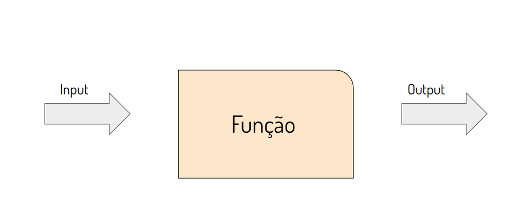

- argumentos(input) - É onde passamos os dados que a função “espera”.
- retorno(output) - É o retorno após o “processamento” do dado.

### **Documentação**

Antes de utilizar as funções no R, é importante sabermos o que elas fazem, quais argumentos esperam e qual seu retorno. Um caminho rápido é utilizando os comandos:

```r
help(sample)

?sample
```

Outra maneira de obter os argumentos de uma função é utilizando o comando `args()`.

```r
args(sample)
```

```
## function (x, size, replace = FALSE, prob = NULL)
## NULL
```

### **Uso de funções**

Sabendo acessar a documentação e o que deve ser passado de parâmetro para cada função, a utilização das mesmas é fácil. Basta chamar a função passando os argumentos e “pegar” a resposta esperada.

```r
linkedin <- c(16, 9, 13, 5, 2, 17, 14)
facebook <- c(17, 7, 5, 16, 8, 13, 14)

mean(linkedin)

max(facebook)

summary(linkedin)
```

- **Lidando com `NA`**

Algumas funções não conseguem lidar com dados faltantes, tais como: `mean`, `max`, entre outras. Portanto, sempre é interessante analisarmos se há dados faltantes e “avisar” a função para ela estar preparada pra lidar com isso.

```r
linkedin <- c(16, 9, NA, 5, 2, 17, 14)

# não soma
mean(linkedin)
```

```
## [1] NA
```

```r
# correto
mean(linkedin, na.rm = TRUE)
```

```
## [1] 10.5
```

- **Funções dentro de funções**

Como você sabe, o R retorna objetos de funções que você pode utilizar posteriormente. Isso facilita o uso de funções dentro de funções, como podemos ver no exemplo a seguir:

```r
velocidade <- 31

print(paste("Sua velocidade é:", velocidade))
```

```
## [1] "Sua velocidade é: 31"
```

Note que estamos utilizando a função `paste` para concatenar um texto e um valor em uma string e depois estamos “printando” na tela.

Suponha que temos os “views” diários do linkedin de do facebook dos nossos perfis. Queremos fazer a diferença absoluta média de views das redes sociais:

```r
linkedin <- c(16, 9, 13, 5, NA, 17, 14)

facebook <- c(17, NA, 5, 16, 8, 13, 14)

mean(abs(linkedin - facebook), na.rm = T)
```

```
## [1] 4.8
```

### **Escrevendo Funções**

Quando devemos escrever funções? Basicamente, quando temos de resolver um problema particular e bem definido. Há uma frase famosa que diz: “Se você teve que escrever a mesma lógica mais de 2 vezes em um código, escreva uma função”.

A estrutura de uma função no R é dada pela sintaxe a seguir:

```r
minha_fun <- function(arg1, arg2) {
  código
}
```

#### **Argumentos**

- **Argumentos Obrigatórios**

Argumentos são os “inputs” que temos de passar para as funções e são declarados no ínicio. No exemplo abaixo, temos uma função que tem como input um número e como output o número elevado ao quadrado:

```r
quadrado <- function(x) {

  y <- x ^ 2

  return(y)
}

quadrado(5)
```

```
## [1] 25
```

Note que utilizamos o argumento `return()` para “devolver” o valor calculado. Essa função é essencial para que após a execução do código dentro da função, possamos retornar um valor para o ambiente global.

- **Argumentos opcionais**

Na maioria das funções temos argumentos que são essenciais e outros que são opcionais, ou seja, argumentos que não são obrigatórios. Seguindo o exemplo anterios, na função `mean` o argumento `na.rm` não é obrigatório.

```r
linkedin <- c(16, 9, NA, 5, 2, 17, 14)

mean(linkedin, na.rm = TRUE)
```

Quando estamos criando uma função, para declararmos um argumento opcional, devemos estabelecer um valor fixo para ele, como na sintaxe abaixo:

```r
minha_fun <- function(arg1, arg2 = val2) {
  codigo
}
```

- **Sem argumentos**

Há também situações em que não precisamos necessariamente de argumentos em uma função, como mostrado abaixo:

```r
# função para sortear um número entre 1 e 10

sorteia_number <- function() {
  number <- sample(1:10, size = 1)

  return(number)
}

sorteia_number()
```

```
## [1] 10
```

#### **Ambiente**

Quando declaramos uma variável dentro de uma função, isto implica que aquela variável irá existir apenas no ambiente da função. No exemplo da função que eleva um número ao quadro, a variável `x` e `y` só existem dentro da função.

```r
quadrado <- function(x) {

  y <- x ^ 2

  return(y)
}
```

Tais variáveis que só existem dentro de uma função são chamadas de **variáveis locais**. Já as outras que estão no ambiente global, são chamadas de **variáveis globais**.

Caso você queira adicionar uma variável global dentro de um função, basta utilizar o operador `<<-`.

```r
quadrado <- function(x) {

  y <<- x ^ 2

  return(y)
}
```

> Let’s do
- Faça uma função que tenha como parâmetro dois números e retorne a soma absoluta deles.
- Faça uma função que receba um vetor contendo `NA` e remova-os, posteriormente retorne um vetor sem os valores faltantes.

## Pacotes

Você deve ter notado que inúmeras vezes utilizamos funções, tais como: `mean`, `max` e etc. No ambiente do R, todas funções implementadas são advindas de algum pacote, as utilizadas até aqui são provenientes de pacotes já “carregados” no R, como o **base** e **mass**. Porém, existe uma infinidade de pacotes que podem ser instalados para diferentes funcionalidades.

### Instalando pacotes

- **`install.packages()`**

As versões estáveis de pacotes do R ficam armazenadas no [CRAN](https://cran.r-project.org/web/packages/available_packages_by_name.html) e são instaladas através do comando `install.packages`

```r
install.packages("dplyr")
```

- **`install_github`**

Além das versões estáveis de pacotes, há também versões em desenvolvimento, situadas em sua maioria no portal de códigos [github](https://github.com/). Para instalar as versões em dev, bast utilizar a função `install_github` do pacote **devtools**.

```r
devtools::install_github("tidyverse/dplyr")
```

### Carregamento

Após a instalação do pacote em sua máquina, para utilizar no seu ambiente basta utilizar uma das funções `require()` ou `library`

```r
library(dplyr)

data("iris")

iris_filtrado <- filter(iris, Sepal.Length > 4) # filter é uma função do pacote dplyr

head(iris_filtrado)
```

```
##   Sepal.Length Sepal.Width Petal.Length Petal.Width Species
## 1          5.1         3.5          1.4         0.2  setosa
## 2          4.9         3.0          1.4         0.2  setosa
## 3          4.7         3.2          1.3         0.2  setosa
## 4          4.6         3.1          1.5         0.2  setosa
## 5          5.0         3.6          1.4         0.2  setosa
## 6          5.4         3.9          1.7         0.4  setosa
```

## Desafio

1. Faça um função que recebe um salário e calcula o imposto de renda que o indivíduo deve pagar.
2. Faça uma função que recebe como argumento um número e retorna um valor lógico dizendo se o número é primo ou não (`TRUE` ou `FALSE`). Dica: Utilize `for`, `if` e o resto da divisão `%%`

   2.2 Utilizando `for` veja quais números de 1 a 100 são primos, guarde a resposta em um vetor e depois mostre quais número são primos. Dica: utilize o vetor que contém a resposta como “filtro” para mostrar na tela os números primos.